# GSB 544 Lab 7

Author

Eddie Cagney

# Setup

```python
import pandas as pd
from sklearn.pipeline import Pipeline
from sklearn.neighbors import KNeighborsRegressor, KNeighborsClassifier
from sklearn.tree import DecisionTreeRegressor
from sklearn.pipeline import Pipeline
from sklearn.compose import make_column_selector, ColumnTransformer
from sklearn.preprocessing import StandardScaler, OneHotEncoder, PolynomialFeatures
from sklearn.linear_model import LinearRegression, Ridge, Lasso, ElasticNet, LogisticRegression
from sklearn.model_selection import train_test_split, cross_val_score, GridSearchCV
from sklearn.metrics import r2_score, confusion_matrix, ConfusionMatrixDisplay, accuracy_score, cohen_kappa_score, precision_score, recall_score, roc_auc_score
import numpy as np
from sklearn.tree import DecisionTreeClassifier, DecisionTreeRegressor
```

```python
ha = pd.read_csv("https://www.dropbox.com/s/aohbr6yb9ifmc8w/heart_attack.csv?dl=1")
```

# Part 1

**Knn**

```python
X = ha[["age", "sex", "chol", "thalach", "cp"]]
y = ha["output"]

ct_kmeans = ColumnTransformer(
  [
    ("dummify",
    OneHotEncoder(sparse_output = False, handle_unknown='ignore'),
    make_column_selector(dtype_include=object)),
    ("standardize",
    StandardScaler(),
    make_column_selector(dtype_include=np.number))
  ],
  remainder = "passthrough"
)

pipeline_knn = Pipeline(
  [("preprocessing", ct_kmeans),
  ("knn", KNeighborsClassifier(n_neighbors = 5))]
)

degrees = {'knn__n_neighbors': [5,10,15,20,25]}
gscv_ridge = GridSearchCV(pipeline_knn, degrees, cv = 5, scoring='roc_auc')
gscv_ridge_fitted = gscv_ridge.fit(X,y)
table = pd.DataFrame(data = {"degrees": [5,10,15,20,25], "scores": gscv_ridge_fitted.cv_results_['mean_test_score']})
best_score_knn = table.iloc[3,1]

print(table)
print(f'The best roc auc metric is {best_score_knn}')

best_n = gscv_ridge_fitted.best_params_['knn__n_neighbors']
```

```
   degrees    scores
0        5  0.807108
1       10  0.836342
2       15  0.833931
3       20  0.845340
4       25  0.842886
The best roc auc metric is 0.845340406719717
```

```python
pipeline_knn = Pipeline(
  [("preprocessing", ct_kmeans),
  ("knn", KNeighborsClassifier(n_neighbors = best_n))]
)

knn = pipeline_knn.fit(X,y)

y_train_ = pd.Series(knn.predict(X), name = "Predicted")
print(pd.crosstab(y, y_train_, margins=True))
```

```
Predicted    0    1  All
output
0          101   26  127
1           33  113  146
All        134  139  273
```

Attempted to fit the model predicting output with the rest of the variables in the dataset, but found that doing so led to overfitting of the model, so we took out the variable `restecg` which helped. From doing cross validation, found that the best number of nearest neighbors was 20, giving us an ROC AUC score around 0.845.

**Logistic Regression**

```python
ct_logistic = ColumnTransformer(
  [
    ("dummify",
    OneHotEncoder(sparse_output = False, handle_unknown='ignore'),
    make_column_selector(dtype_include=object)),
    ("standardize",
    StandardScaler(),
    make_column_selector(dtype_include=np.number))
  ],
  remainder = "passthrough"
)

pipeline_logistic = Pipeline(
  [("preprocessing", ct_logistic),
  ("logit_step", LogisticRegression(max_iter = 1000, C = 1, penalty="l2", solver="lbfgs"))]
)

degrees = {'logit_step__C': [2,3,4,5,6]}
gscv_ridge = GridSearchCV(pipeline_logistic, degrees, cv = 5, scoring='roc_auc')
gscv_ridge_fitted = gscv_ridge.fit(X,y)
table = pd.DataFrame(data = {"degrees": [2,3,4,5,6], "scores": gscv_ridge_fitted.cv_results_['mean_test_score']})
best_score_logit = table.iloc[1,1]

print(table)
print(f'The best roc auc metric is {best_score_logit}')

best_c = gscv_ridge_fitted.best_params_['logit_step__C']
```

```
   degrees    scores
0        2  0.847808
1        3  0.848349
2        4  0.848349
3        5  0.848084
4        6  0.848084
The best roc auc metric is 0.8483494252873562
```

```python
pipeline_logistic = Pipeline(
  [("preprocessing", ct_kmeans),
  ("logit_step", LogisticRegression(max_iter = 1000, C = best_c, penalty="l2", solver="lbfgs"))]
)

logistic = pipeline_logistic.fit(X,y)

y_train_ = pd.Series(logistic.predict(X), name = "Predicted")
print(pd.crosstab(y, y_train_, margins=True))

clf = logistic.named_steps['logit_step']
coefs = clf.coef_
intercept = clf.intercept_
print(coefs)
print(intercept)
```

```
Predicted    0    1  All
output
0           90   37  127
1           26  120  146
All        116  157  273
[[-0.37759533 -0.95459341 -0.32567541  0.83261245  0.82232375]]
[0.20713758]
```

Sticking to the same variables that was decided for the KKN model, the logistic regression was performed with tuning on its regularization element. With a higher “C” the model tends to allow the coefficients to grow/ be more flexible. However, this can lead to overfitting which is the reason why we tune with cross validation, which resulted in the best hyperparameter being `best_c`. Based on the roc_auc_score, it appears that this model predicts better than the KKN model previously used, given the higher roc auc. The coefficients in the logistic regression represent the log-odds of the outcome (and the change of those odds) for a one unit change in the predictor.

**Decision Tree**

```python
ct_tree = ColumnTransformer(
  [
    ("dummify",
    OneHotEncoder(sparse_output = False, handle_unknown='ignore'),
    make_column_selector(dtype_include=object))
  ],
  remainder = "passthrough"
)

pipeline_tree = Pipeline(
  [("preprocessing", ct_tree),
  ("decision_tree", DecisionTreeClassifier(max_depth=None, min_impurity_decrease = 0))]
)

degrees = {'decision_tree__min_impurity_decrease': [0, 0.01, 0.0001]}
gscv_ridge = GridSearchCV(pipeline_tree, degrees, cv = 5, scoring='roc_auc')
gscv_ridge_fitted = gscv_ridge.fit(X,y)
table = pd.DataFrame(data = {"degrees": [0, 0.01, 0.0001], "scores": gscv_ridge_fitted.cv_results_['mean_test_score']})
best_score_tree = table.iloc[1,1]

print(table)
print(f'The best roc auc metric is {best_score_tree}')


best_depth = gscv_ridge_fitted.best_params_['decision_tree__min_impurity_decrease']
```

```
   degrees    scores
0   0.0000  0.647323
1   0.0100  0.780654
2   0.0001  0.659965
The best roc auc metric is 0.780654288240495
```

```python
pipeline_tree = Pipeline(
  [("preprocessing", ct_tree),
  ("decision_tree", DecisionTreeClassifier(max_depth=None, min_impurity_decrease = best_depth))]
)

tree = pipeline_tree.fit(X,y)

y_train_ = pd.Series(tree.predict(X), name = "Predicted")
print(pd.crosstab(y, y_train_, margins=True))
```

```
Predicted    0    1  All
output
0           92   35  127
1           17  129  146
All        109  164  273
```

For the decision tree model, I originally was tuning based off of max_depth. After doing this I realized that this wasn’t necessarily improving the overall predictions of my model. So, I went and found a weight to tune that would do so, that being the min_impurity_decrease. From there I was able to find the best roc auc which was min_impurity_decrease of 0.01.

**Q5**

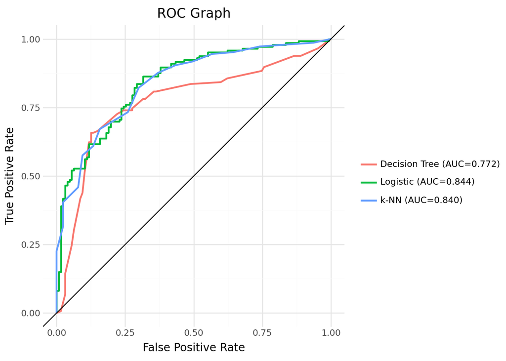

```python
from plotnine import *
from sklearn.model_selection import cross_val_predict
from sklearn.metrics import roc_curve, roc_auc_score

models = [
    ("k-NN", pipeline_knn),
    ("Logistic", pipeline_logistic),
    ("Decision Tree", pipeline_tree),
]


rows, labels = [], {}
for name, pipe in models:
    y_score = cross_val_predict(pipe, X, y, cv = 5, method="predict_proba")[:, 1]
    fpr, tpr, _ = roc_curve(y, y_score)
    auc_val = roc_auc_score(y, y_score)
    labels[name] = f"{name} (AUC={auc_val:.3f})"
    rows.append(pd.DataFrame({"fpr": fpr, "tpr": tpr, "model": name}))

roc_df = pd.concat(rows, ignore_index=True)
roc_df["label"] = roc_df["model"].map(labels)

(
    ggplot(roc_df, aes("fpr", "tpr", color="label"))
    + geom_line(size=1.0)
    + geom_abline(slope=1, intercept=0)
    + coord_equal()
    + labs(title="ROC Graph",
    x="False Positive Rate",
    y="True Positive Rate", color="")
    + theme_minimal()
)
```

# Part 2

**Knn**

```python
from sklearn.metrics import make_scorer

knn_recall = cross_val_score(pipeline_knn, X, y, cv = 5, scoring = 'recall').mean()
knn_precision = cross_val_score(pipeline_knn, X, y, cv = 5, scoring = 'precision').mean()
knn_scorer = make_scorer(recall_score, pos_label=0)
knn_specificity = cross_val_score(pipeline_knn, X, y, cv=5, scoring = knn_scorer, n_jobs=-1).mean()
knn_recall,knn_precision,knn_specificity
```

```
(np.float64(0.7326436781609195),
 np.float64(0.7684415584415586),
 np.float64(0.7393846153846154))
```

**Logistic**

```python
logistic_recall = cross_val_score(pipeline_logistic, X, y, cv = 5, scoring = 'recall').mean()
logistic_precision = cross_val_score(pipeline_logistic, X, y, cv = 5, scoring = 'precision').mean()
logistic_scorer = make_scorer(recall_score, pos_label=0)
logistic_specificity = cross_val_score(pipeline_logistic, X, y, cv = 5, scoring = logistic_scorer, n_jobs=-1).mean()
logistic_recall, logistic_precision, logistic_specificity
```

```
(np.float64(0.8149425287356322),
 np.float64(0.770256734006734),
 np.float64(0.7160000000000001))
```

**Decision Tree**

```python
tree_recall = cross_val_score(pipeline_tree, X, y, cv = 5, scoring = 'recall').mean()
tree_precision = cross_val_score(pipeline_tree, X, y, cv = 5, scoring = 'precision').mean()
tree_scorer = make_scorer(recall_score, pos_label=0)
tree_specificity = cross_val_score(pipeline_tree, X, y, cv = 5, scoring = tree_scorer, n_jobs=-1).mean()
tree_recall, tree_precision, tree_specificity
```

```
(np.float64(0.7262068965517241),
 np.float64(0.7950680864473967),
 np.float64(0.7787692307692308))
```

# Part 3

**Q1** The metric I would use would be recall, this is because if we deem a person “low risk” thats the same as predicting they will not have a heart attack. If we focus on making recall the highest it can be, this would increase the proportion of correct predictions for a at-risk person of having a heart attack, however will still be playing it safe regaurding accidentally labeling someone as low-risk and they do end up having a heart attack. If I decide to use recall then the model I would suggest is the logistic model given that that model had the best recall score and I should expect the same recall score for future observations.

**Q2** In this case I would use precision. This would help the hospital staff identify the proportion of at-risk individuals that actually need the bed-space to monitor their chance of having a heart attack (basically trying to maximize the amount of people labeld at-risk with the actual amount of people who are at risk). The best model for precision is the Decision tree model with it having the best precision score which should be reflected when we make new predictions.

**Q3** For this situation, the context doesn’t push me to select any particular metric to determine the model selection (could use roc auc for overall fit). However, I would select the decision tree model because the area of interest in among the predictors, which the decision tree gives good insight on.

**Q4** This example is also not leading me to select any particular metric for model selection because we are not interested in specifically the true positives or true negatives but rather the overall accuracy of the doctors. My suggested model would be the logistic model as it can give a set of log odds for the predictions of the doctors.

# Part 4

```python
ha_validation = pd.read_csv("https://www.dropbox.com/s/jkwqdiyx6o6oad0/heart_attack_validation.csv?dl=1")
```

```python
X_new = ha_validation[["age", "sex", "chol", "thalach", "cp"]]
y_new = ha_validation["output"]
```

**KNN**

```python
y_train_ = pd.Series(knn.predict(X_new), name = "Predicted")
print(pd.crosstab(y_new, y_train_, margins=True))

knn_recall_new = cross_val_score(pipeline_knn, X_new, y_new, cv = 5, scoring = 'recall').mean()
knn_precision_new = cross_val_score(pipeline_knn, X_new, y_new, cv = 5, scoring = 'precision').mean()
knn_roc_auc_new = cross_val_score(pipeline_knn, X_new, y_new, cv = 5, scoring = 'roc_auc').mean()

print(f'New Scores:\n Recall: {knn_recall_new}\n Precision: {knn_precision_new}\n Roc Auc:{knn_roc_auc_new}')
print(f'Old Scores:\n Recall: {knn_recall}\n Precision: {knn_precision}\n Roc Auc:{best_score_knn}')
```

```
Predicted   0   1  All
output
0          11   0   11
1           6  13   19
All        17  13   30
New Scores:
 Recall: 1.0
 Precision: 0.6333333333333333
 Roc Auc:0.675
Old Scores:
 Recall: 0.7326436781609195
 Precision: 0.7684415584415586
 Roc Auc:0.845340406719717
```

**Logistic**

```python
y_train_ = pd.Series(logistic.predict(X_new), name = "Predicted")
print(pd.crosstab(y_new, y_train_, margins=True))

logistic_recall_new = cross_val_score(pipeline_logistic, X_new, y_new, cv = 5, scoring = 'recall').mean()
logistic_precision_new = cross_val_score(pipeline_logistic, X_new, y_new, cv = 5, scoring = 'precision').mean()
logistic_roc_auc_new = cross_val_score(pipeline_logistic, X_new, y_new, cv = 5, scoring = 'roc_auc').mean()

print(f'New Scores:\n Recall: {logistic_recall_new}\n Precision: {logistic_precision_new}\n Roc Auc:{logistic_roc_auc_new}')
print(f'Old Scores:\n Recall: {logistic_recall}\n Precision: {logistic_precision}\n Roc Auc:{best_score_logit}')
```

```
Predicted   0   1  All
output
0           9   2   11
1           5  14   19
All        14  16   30
New Scores:
 Recall: 0.75
 Precision: 0.6533333333333333
 Roc Auc:0.85
Old Scores:
 Recall: 0.8149425287356322
 Precision: 0.770256734006734
 Roc Auc:0.8483494252873562
```

**Decision Tree**

```python
y_train_ = pd.Series(tree.predict(X_new), name = "Predicted")
print(pd.crosstab(y_new, y_train_, margins=True))

tree_recall_new = cross_val_score(pipeline_tree, X_new, y_new, cv = 5, scoring = 'recall').mean()
tree_precision_new = cross_val_score(pipeline_tree, X_new, y_new, cv = 5, scoring = 'precision').mean()
tree_roc_auc_new = cross_val_score(pipeline_tree, X_new, y_new, cv = 5, scoring = 'roc_auc').mean()

print(f'New Scores:\n Recall: {tree_recall_new}\n Precision: {tree_precision_new}\n Roc Auc:{tree_roc_auc_new}')
print(f'Old Scores:\n Recall: {tree_recall}\n Precision: {tree_precision}\n Roc Auc:{best_score_tree}')
```

```
Predicted   0   1  All
output
0           9   2   11
1           4  15   19
All        13  17   30
New Scores:
 Recall: 0.8333333333333334
 Precision: 0.7866666666666666
 Roc Auc:0.55
Old Scores:
 Recall: 0.7262068965517241
 Precision: 0.7950680864473967
 Roc Auc:0.780654288240495
```

# Part 5

From what I can gather from the internet, the Cohen’s Kappa is a metric that takes into account the random chance of having predictions match the actual results. Sort of like saying “how often did we actually make the right diagnosis, rather than just happen by chance to choose the right one”.

```python
cohen_kappa = make_scorer(cohen_kappa_score)

knn_ck = cross_val_score(pipeline_knn, X, y, cv = 5, scoring = cohen_kappa).mean()
logistic_ck = cross_val_score(pipeline_logistic, X, y, cv = 5, scoring = cohen_kappa).mean()
tree_ck = cross_val_score(pipeline_tree, X, y, cv = 5, scoring = cohen_kappa).mean()

print(f'Cohen Kappa Scores:\n Knn: {knn_ck}\n Logit: {logistic_ck}\n Tree:{tree_ck}')
```

```
Cohen Kappa Scores:
 Knn: 0.4708880026625398
 Logit: 0.5334032374785085
 Tree:0.5020327291718824
```